# Project-Meeting-2-Demonstration

Raghuveer Venkatesh

2024-12-03

## Main Project Goal

The main objective of this project is to create a regression model that can accurately predict a FIFA football strikers market value. This is done by diving deep into various attributes like performance metrics, physical traits, and Player stats - age, height, weight. This analysis aims to uncover the factors that truly drive a player’s worth in the transfer market.

This will give Clubs and Agents the clarity they need to make smarter, more informed decisions. It can pinpoint undervalued talent, justify big-money investments, or even identify traits that consistently lead to higher market valuations.

Specifically for the team’s manager, this could mean having a competitive edge during negotiations. For the scouting team, it’s about finding hidden gems that others might overlook. Finance teams get clarity on the ROI of expensive signings, while the coaching staff gains insights into which traits best align with the team’s style of play.

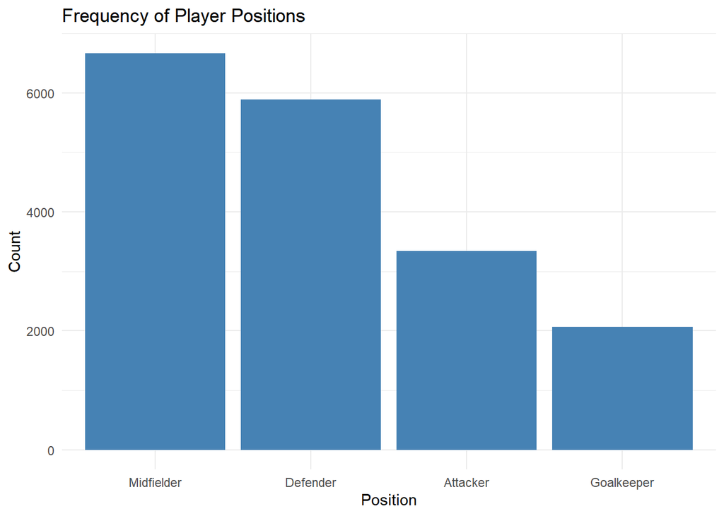

```r
fifa_data <- fifa_data |>
  mutate(
    first_position = str_extract(positions, "^[^,]+")
  )

fifa_data <- fifa_data |>
  mutate(
    position_category = case_when(
      first_position %in% c("ST", "RW", "LW", "CF") ~ "Attacker",
      first_position %in% c("CAM", "CM", "LM", "RM", "CDM") ~ "Midfielder",
      first_position %in% c("CB", "LB", "RB", "LWB", "RWB") ~ "Defender",
      first_position == "GK" ~ "Goalkeeper",
      TRUE ~ "Unknown"
    )
  )


fifa_data |> count(position_category) |>
  arrange(desc(n)) |>
  ggplot(aes(x = reorder(position_category, -n), y=n)) +
  geom_bar(stat = "identity", fill = "steelblue") +
  theme_minimal() +
  labs(title = "Frequency of Player Positions", x = "Position", y = "Count")
```

```r
# Filtering for only Attackers

fifa_data <-  filter(fifa_data, position_category == "Attacker")
```

*Let’s start off by looking at some key attributes of our population to understand a bit about the data using some summary statistics*

```r
# Summarize the data
summary_table <- fifa_data |>
  select(age, height_cm, weight_kgs) |>
  summary()

print(summary_table)
```

```
##       age          height_cm       weight_kgs
##  Min.   :17.00   Min.   :152.4   Min.   : 49.9
##  1st Qu.:21.00   1st Qu.:154.9   1st Qu.: 69.9
##  Median :25.00   Median :175.3   Median : 74.8
##  Mean   :25.12   Mean   :174.1   Mean   : 75.3
##  3rd Qu.:28.00   3rd Qu.:185.4   3rd Qu.: 79.8
##  Max.   :40.00   Max.   :200.7   Max.   :110.2
```

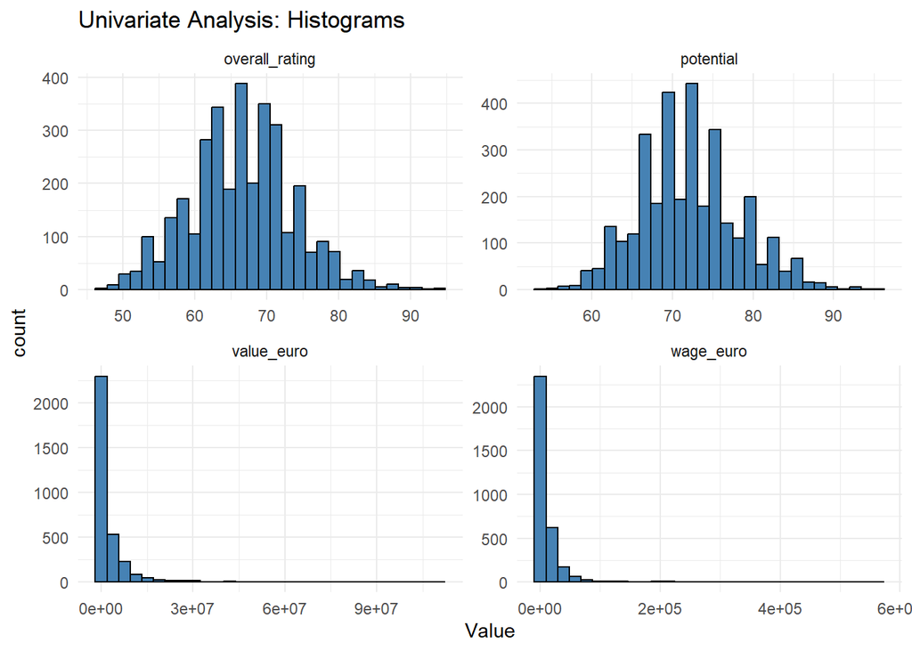

```r
fifa_data |>
  select(overall_rating, potential, value_euro, wage_euro) |>
  pivot_longer(everything(), names_to = "Variable", values_to = "Value") |>
  ggplot(aes(x = Value)) +
  geom_histogram(bins = 30, fill = "steelblue", color = "black") +
  facet_wrap(~Variable, scales = "free") +
  theme_minimal() +
  labs(title = "Univariate Analysis: Histograms")
```

**Summary Statistics** - Mean age: 25.12 years - Total age range: 17-40 years

Physical attributes - Median height is 175.3 cm - Median weight is 74.8 kg

**As we have a lot of traits, let’s pick out the specific traits which are important to us**

We start off by picking the top Physical traits and traits specific to football like finishing, dribbling, stamina, strength etc.., to address our issue. This is done by creating a correlation matrix of the attributes.

### Correlation Matrix

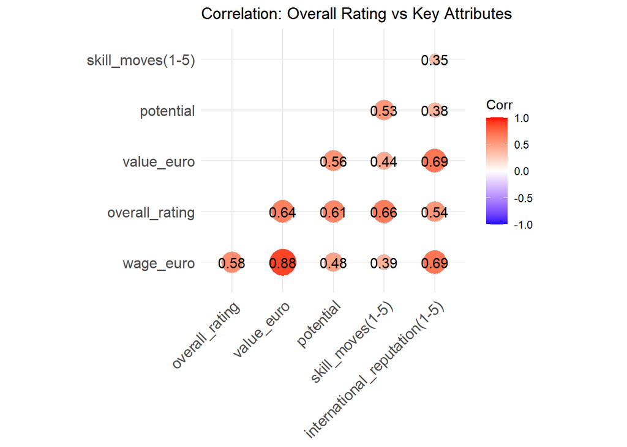

```r
key_attributes <- fifa_data |>
  select(wage_euro,overall_rating, value_euro, potential, `skill_moves(1-5)`, `international_reputation(1-5)`)

# Compute the correlation matrix
cor_matrix_key <- cor(key_attributes, use = "complete.obs")

ggcorrplot(cor_matrix_key,
           method = "circle",
           type = "lower",
           lab = TRUE,
           title = "Correlation: Overall Rating vs Key Attributes",
           colors = c("blue", "white", "red"))
```

**Observation**: Overall rating, wage and international reputation have the highest correlation to the value in euro for a particular player.

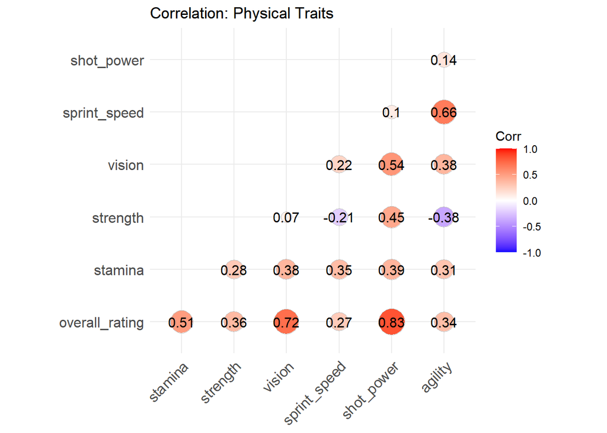

```r
physical_traits <- fifa_data |>
  select(overall_rating, stamina, strength, vision, sprint_speed, shot_power, agility)

# Compute the correlation matrix
cor_matrix_physical <- cor(physical_traits, use = "complete.obs")

ggcorrplot(cor_matrix_physical,
           method = "circle",
           type = "lower",
           lab = TRUE,
           title = "Correlation: Physical Traits",
           colors = c("blue", "white", "red"))
```

**Observation**: Stamina, Vision and Shot power most impactful attributes to the overall rating of a particular player which based on the previous matrix strongly determines the value of the particular player in the international transfer market.

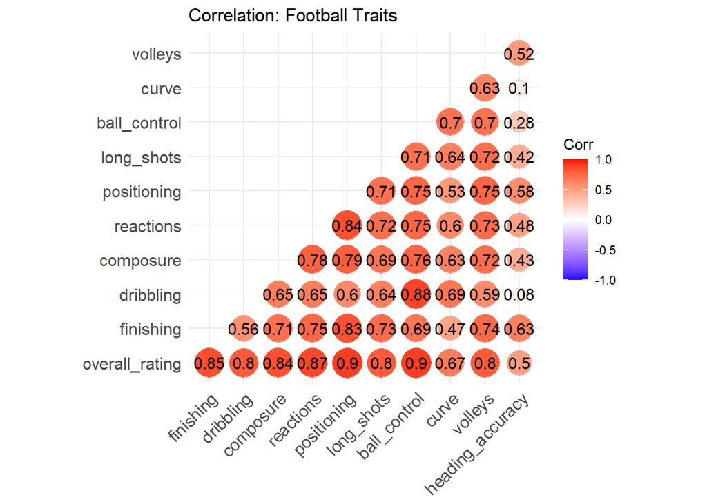

```r
football_traits <- fifa_data |>
  select(overall_rating, finishing, dribbling, composure, reactions, positioning,
         long_shots, ball_control, curve, volleys, heading_accuracy)

# Compute the correlation matrix
cor_matrix_football <- cor(football_traits, use = "complete.obs")

ggcorrplot(cor_matrix_football,
           method = "circle",
           type = "lower",
           lab = TRUE,
           title = "Correlation: Football Traits",
           colors = c("blue", "white", "red"))
```

**Observations** finishing, dribbling, composure, reactions, positioning, long shots, ball control and volleys have the highest correlation to the overall rating Based on these observations, we can pick the traits below for further analysis which show a high correlation towards the overall rating.

**Football traits**: finishing, dribbling, composure, reactions, positioning, long_shots, ball_control, volleys. **Physical traits**: shot power, vision, stamina

# Exploratory Data Analysis

### Uni-variate ANalysis: Descriptive Analysis of the values - Football and Physical traits to find the rare traits and commond traits

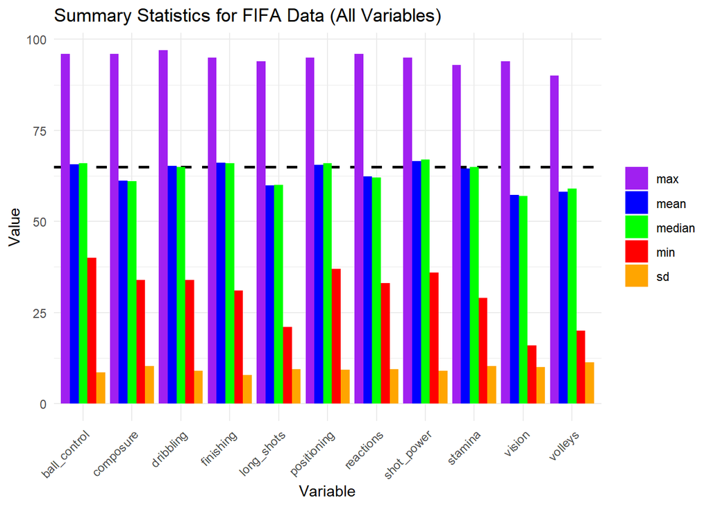

```r
summary_data <- fifa_data |>
  select(stamina, dribbling, finishing, vision, shot_power, composure, reactions, positioning, long_shots, ball_control, volleys) |>
  summarise_all(list(mean = mean, median = median, sd = sd, min = min, max = max), na.rm = TRUE)

# Reshaping the data to long format for ggplot2
summary_long <- summary_data |>
  pivot_longer(cols = everything(),
               names_to = c("variable", "statistic"),
               names_pattern = "(.*)_(.*)",
               values_to = "value")

# Plotting the summary statistics for all variables
ggplot(summary_long, aes(x = variable, y = value, fill = statistic)) +
  geom_hline(yintercept = 65, color = "black", size = 1, linetype = "dashed") +
  geom_bar(stat = "identity", position = "dodge") +
  labs(title = "Summary Statistics for FIFA Data (All Variables)",
       x = "Variable",
       y = "Value") +
  scale_fill_manual(values = c("mean" = "blue", "median" = "green", "sd" = "orange", "min" = "red", "max" = "purple")) +
  theme_minimal() +
   theme(axis.text.x = element_text(
    angle = 45, hjust = 1,
  )) +
  theme(legend.title = element_blank())
```

#### Observations

**Common Traits**

- Ball Control - Dribbling - Finishing - Positioning - Shot Power, Stamina

**Rarer Traits**

- Composure - Long Shots - Reactions - Vision - Volleys

### Bi-variate Analysis

Scatter plot: Market Value vs Overall rating

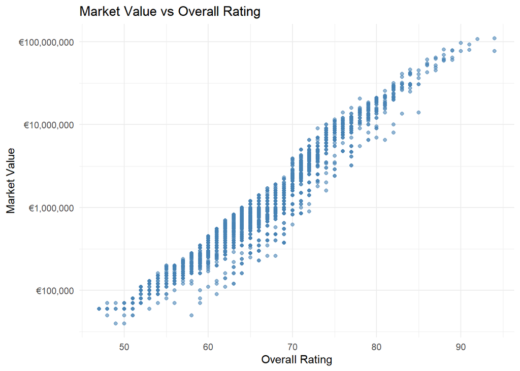

```r
fifa_data |>
  ggplot(aes(x = overall_rating, y = value_euro)) +
  geom_point(alpha = 0.6, color = "steelblue") +
  theme_minimal() +
  scale_y_log10(labels = dollar_format(prefix = "€")) +
  labs(title = "Market Value vs Overall Rating", x = "Overall Rating", y = "Market Value")
```

#### Observations - Market values vs Overall rating

We can see that the Market value increases exponentially when compared to overall rating

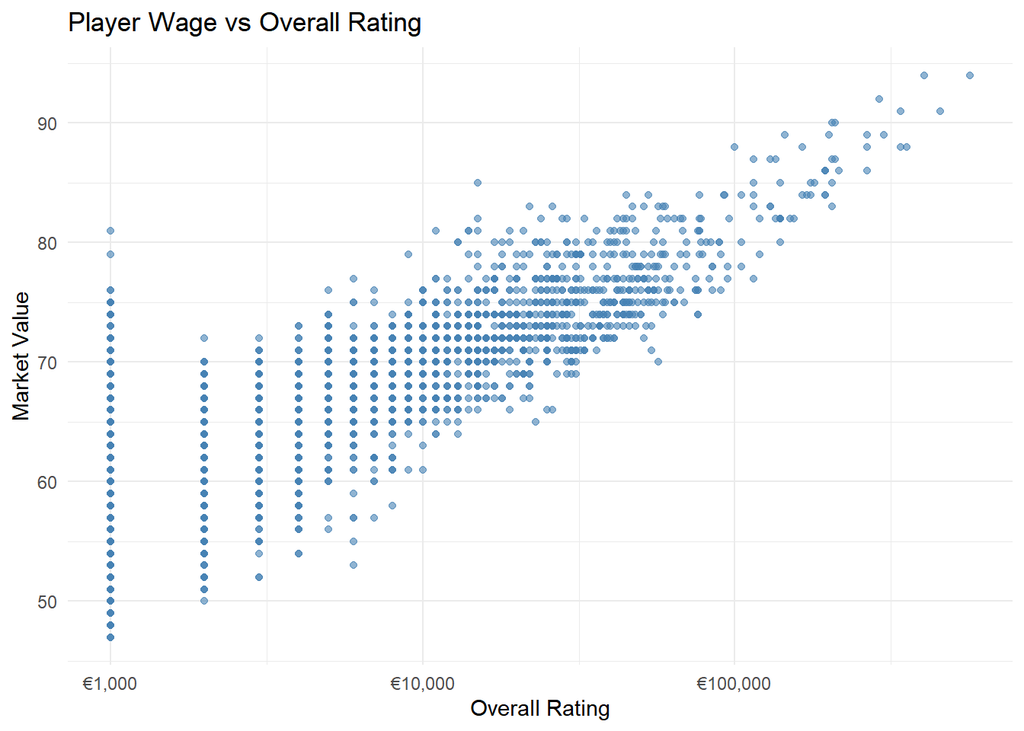

```r
fifa_data |>
  ggplot(aes(y = overall_rating, x = wage_euro)) +
  geom_point(alpha = 0.6, color = "steelblue") +
  theme_minimal() +
  scale_x_log10(labels = dollar_format(prefix = "€")) +
  labs(title = "Player Wage vs Overall Rating", x = "Overall Rating", y = "Market Value")
```

Strong link observed between Overall rating and Market value

```r
fifa_data |>
  group_by(`international_reputation(1-5)`) |>
  summarise(
    avg_value_euro = mean(value_euro, na.rm = TRUE),
    median_value_euro = median(value_euro, na.rm = TRUE),
    count = n()
  ) |>
  arrange(desc(avg_value_euro))
```

```
## # A tibble: 5 × 4
##   `international_reputation(1-5)` avg_value_euro median_value_euro count
##                             <dbl>          <dbl>             <dbl> <int>
## 1                               5      77900000           80000000     5
## 2                               4      48571429.          45750000    14
## 3                               3      23940455.          15750000    88
## 4                               2       8678549.           7000000   259
## 5                               1       1815058.            775000  2972
```

## Observation

Majority of our talent pool has a very low international reputation. Target international reputations would be 1 & 2.

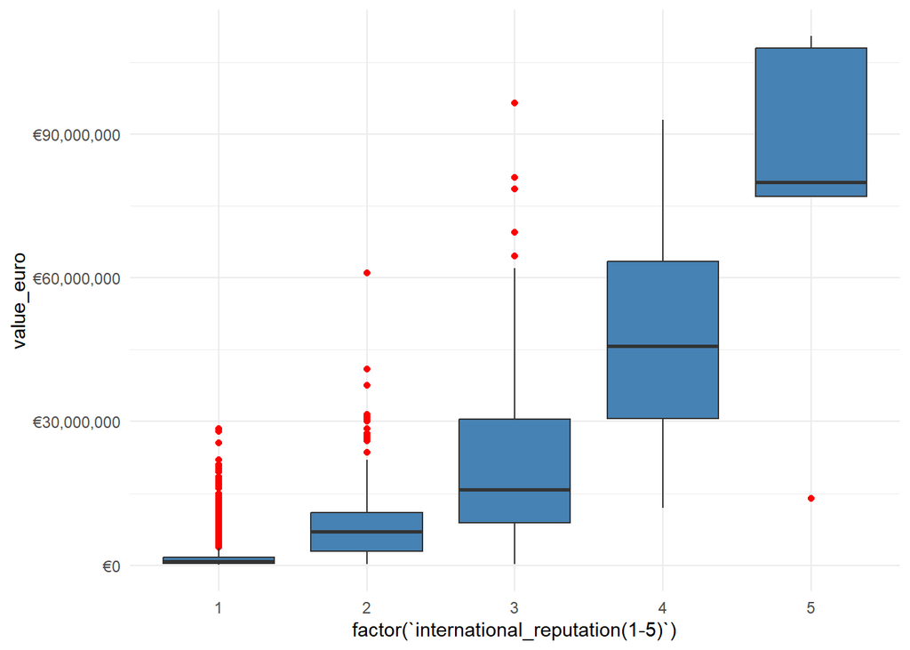

```r
fifa_data |>
  ggplot(aes(x = factor(`international_reputation(1-5)`), y = value_euro)) +
  geom_boxplot(outlier.color = "red", outlier.shape = 16, fill = "steelblue") +
  theme_minimal() +
  scale_y_continuous(labels = dollar_format(prefix = "€"))
```

```r
  labs(
    title = "Distribution of Player Value by International Reputation",
    x = "International Reputation (1-5)",
    y = "Player Value (Euro)"
  )
```

```
## $x
## [1] "International Reputation (1-5)"
##
## $y
## [1] "Player Value (Euro)"
##
## $title
## [1] "Distribution of Player Value by International Reputation"
##
## attr(,"class")
## [1] "labels"
```

### Observatinos - International reputation vs Value

We could see that there is a linear increase with overlap between consecutive international reputation for the value.

## Hypothesis Testing

**Hypothesis 1** Null Hypothesis: Age does not affect players’ market value Alternative Hypothesis: Age affects players’ market value

```r
median_age <- median(fifa_data$age, na.rm = TRUE)
young_players <- fifa_data$value_euro[fifa_data$age < median_age]
older_players <- fifa_data$value_euro[fifa_data$age >= median_age]
model_age <- lm(log(value_euro) ~ age, data = fifa_data)
summary_model = summary(model_age)

p_value <- coef(summary_model)["age", "Pr(>|t|)"]
alpha <- 0.05

if (p_value <= alpha) {
  cat("Reject the null hypothesis: Age significantly affects players' market value.\n")
} else {
  cat("Fail to reject the null hypothesis: Age does not significantly affect players' market value.\n")
}
```

```
## Reject the null hypothesis: Age significantly affects players' market value.
```

## Performing a two sided t-test

```r
fifa_data$age_group <- ifelse(fifa_data$age < median_age, "Young Players", "Older Players")

t.test(value_euro ~ age_group, data = fifa_data, var.equal = FALSE)
```

```
##
##  Welch Two Sample t-test
##
## data:  value_euro by age_group
## t = 8.9852, df = 2655.5, p-value < 2.2e-16
## alternative hypothesis: true difference in means between group Older Players and group Young Players is not equal to 0
## 95 percent confidence interval:
##  1850550 2883723
## sample estimates:
## mean in group Older Players mean in group Young Players
##                     4389851                     2022714
```

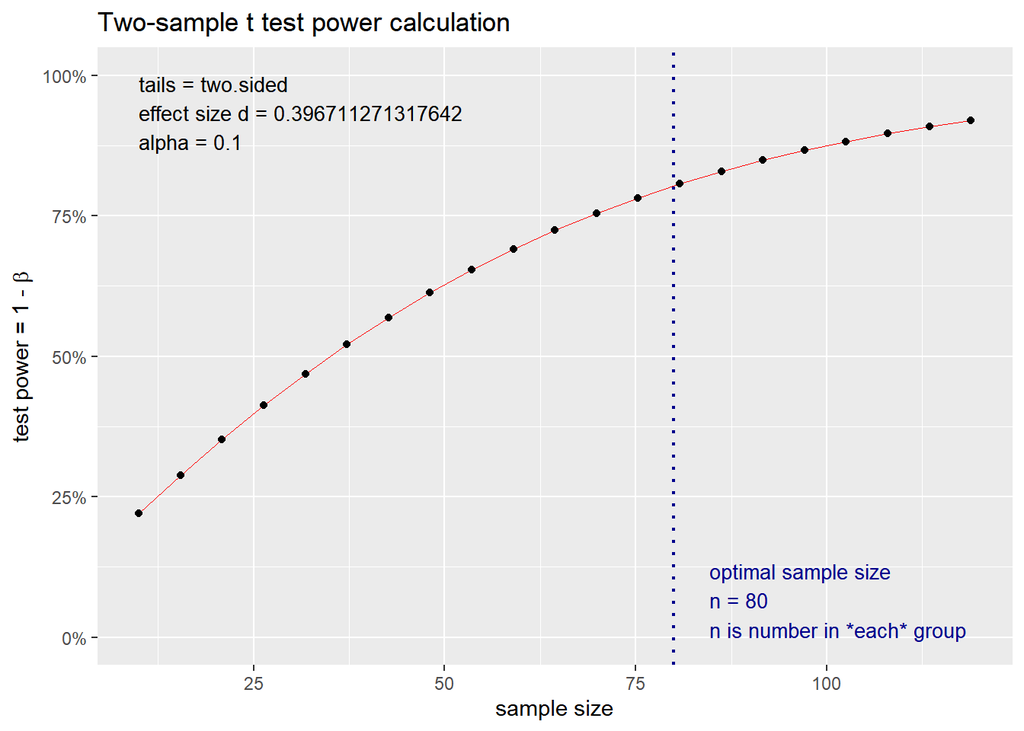

```r
mu1 <- mean(young_players, na.rm = TRUE)
sd1 <- sd(young_players, na.rm = TRUE)

# Perform the power analysis
power_analysis <- pwr.t.test(
  d = (mu1) / sd1,
  power = 0.8,
  sig.level = 0.1,
  type = "two.sample",
  alternative = "two.sided"
)

# Plot the power analysis result
plot(power_analysis)
```

**Hypothesis 2** Null Hypothesis: Potential doesn’t affect a players’ market value Alternative Hypothesis: Potential affects players’ market value

```r
median_potential <- median(fifa_data$potential, na.rm = TRUE)

fifa_data$potential_group <- ifelse(fifa_data$potential < median_potential, "Low Potential", "High Potential")


fifa_data$log_value_euro <- fifa_data$value_euro

t_test_result_potential <- t.test(log_value_euro ~ potential_group, data = fifa_data, var.equal = FALSE)

print(t_test_result_potential)
```

```
##
##  Welch Two Sample t-test
##
## data:  log_value_euro by potential_group
## t = 20.27, df = 1727.7, p-value < 2.2e-16
## alternative hypothesis: true difference in means between group High Potential and group Low Potential is not equal to 0
## 95 percent confidence interval:
##  4525001 5494504
## sample estimates:
## mean in group High Potential  mean in group Low Potential
##                    5649289.9                     639537.4
```

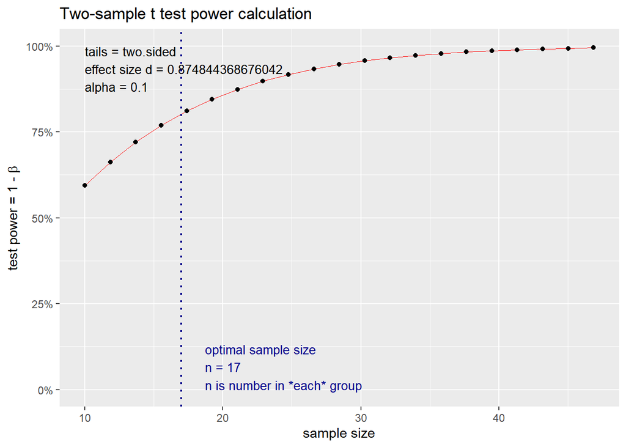

```r
median_potential <- median(fifa_data$potential, na.rm = TRUE)
low_potential <- fifa_data$value_euro[fifa_data$potential < 75]
high_potential <- fifa_data$value_euro[fifa_data$potential >= 75]

mu1 <- mean(low_potential, na.rm = TRUE)
sd1 <- sd(low_potential, na.rm = TRUE)

# Perform the power analysis
power_analysis <- pwr.t.test(
  d = (mu1) / sd1,
  power = 0.8,
  sig.level = 0.1,
  type = "two.sample"
)

# Plot the power analysis result
plot(power_analysis)
```

**Observations** We can see that the p-values for both potential and age are minuscule. Hence, we can safely reject the null hypothesis and can say that both age and potential are statistically significant and must be considered when creating the linear regression model.

### Linear Regression Models

**Linear Regression Model of value ins euro based on age, potential and overall rating.

```r
# Create the linear regression model
log_value_model <- lm(log(value_euro) ~ potential +  overall_rating + age + I(age^2),
                      data = fifa_data)

fifa_data$predicted_value_plot <- exp(predict(log_value_model, fifa_data))


summary(log_value_model)
```

```
##
## Call:
## lm(formula = log(value_euro) ~ potential + overall_rating + age +
##     I(age^2), data = fifa_data)
##
## Residuals:
##      Min       1Q   Median       3Q      Max
## -0.94107 -0.11425 -0.01857  0.12120  0.95088
##
## Coefficients:
##                  Estimate Std. Error t value Pr(>|t|)
## (Intercept)    -2.9377265  0.1962523  -14.97   <2e-16 ***
## potential       0.0392308  0.0018412   21.31   <2e-16 ***
## overall_rating  0.1760239  0.0018499   95.16   <2e-16 ***
## age             0.2098850  0.0129872   16.16   <2e-16 ***
## I(age^2)       -0.0046124  0.0002165  -21.31   <2e-16 ***
## ---
## Signif. codes:  0 '***' 0.001 '**' 0.01 '*' 0.05 '.' 0.1 ' ' 1
##
## Residual standard error: 0.1808 on 3291 degrees of freedom
##   (42 observations deleted due to missingness)
## Multiple R-squared:  0.9837, Adjusted R-squared:  0.9837
## F-statistic: 4.97e+04 on 4 and 3291 DF,  p-value: < 2.2e-16
```

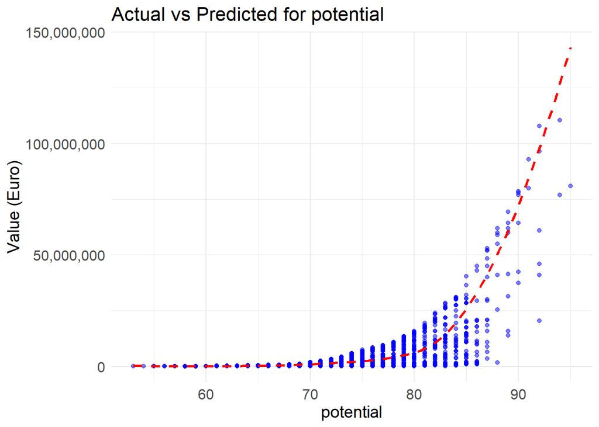

```r
plot_actual_vs_predicted_smooth <- function(predictor, data, actual, predicted) {
  ggplot(data, aes_string(x = predictor)) +
    geom_point(aes_string(y = actual), color = "blue", alpha = 0.5) +
    geom_smooth(aes_string(x = predictor, y = predicted),
                method = "loess",
                color = "red",
                se = FALSE,
                linetype = "dashed",
                size = 1) +
    labs(title = paste("Actual vs Predicted for", predictor),
         x = predictor, y = "Value (Euro)") +
    theme_minimal() +
    scale_y_continuous(labels = scales::comma) +
    theme(plot.title = element_text(size = 16),
          axis.title = element_text(size = 14),
          axis.text = element_text(size = 12))
}

plot_potential <- plot_actual_vs_predicted_smooth("potential", fifa_data, actual = "value_euro", predicted = "predicted_value_plot")
plot_overall_rating <- plot_actual_vs_predicted_smooth("overall_rating", fifa_data, actual = "value_euro", predicted = "predicted_value_plot")

print(plot_potential)
```

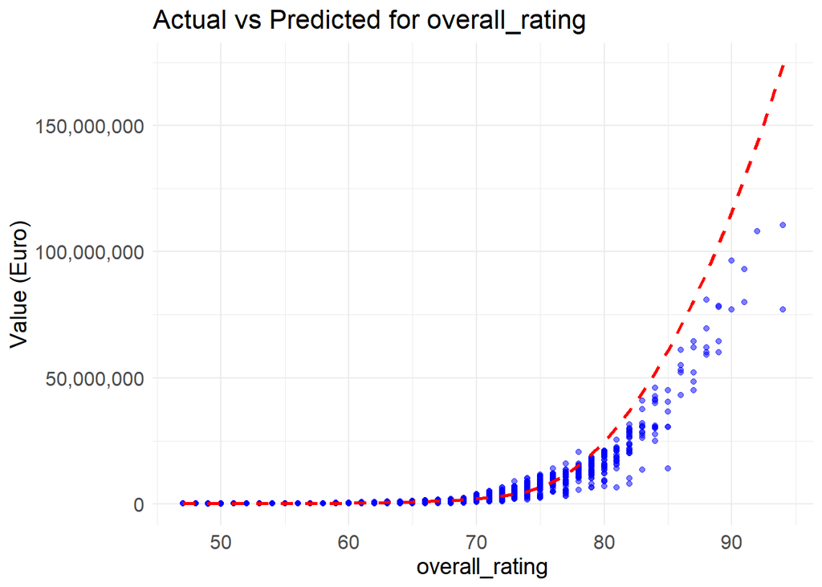

```r
print(plot_overall_rating)
```

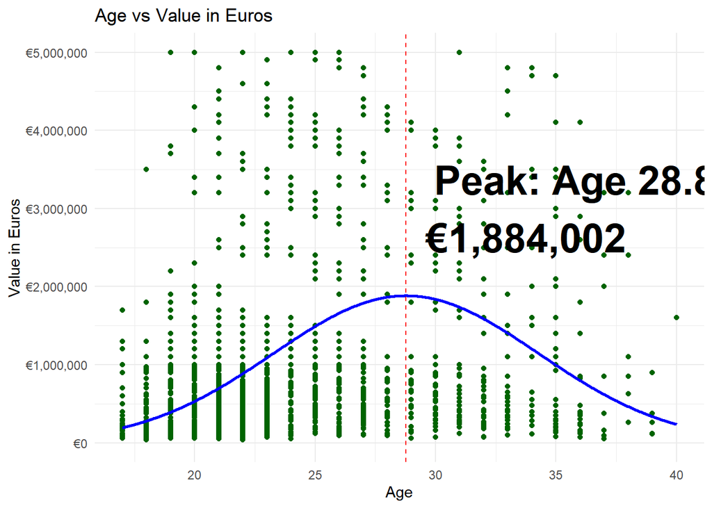

```r
model_age <- lm(log(value_euro) ~ age + I(age^2), data = fifa_data)

age_seq <- seq(min(fifa_data$age), max(fifa_data$age), length.out = 1000)
predicted_log_values <- predict(model_age, newdata = data.frame(age = age_seq))
predicted_values <- exp(predicted_log_values)  # Convert back to Euros

# Create a data frame for predictions
predicted_data <- data.frame(age = age_seq, value_euro = predicted_values)

# Calculate the turning point (peak age)
coefficients <- coef(model_age)
turning_point <- -coefficients["age"] / (2 * coefficients["I(age^2)"])
peak_value <- exp(predict(model_age, newdata = data.frame(age = turning_point)))

# Plot with ggplot2
ggplot(data = fifa_data, aes(x = age, y = value_euro)) +
  geom_point(color = "darkgreen") +  # Scatter plot for actual data
  geom_line(data = predicted_data, aes(x = age, y = value_euro), color = "blue", size = 1) +  # Predicted curve
  geom_vline(xintercept = turning_point, linetype = "dashed", color = "red") +  # Vertical line at the turning point
  annotate("text", x = turning_point, y = peak_value, label = paste0("Peak: Age ", round(turning_point, 1), "\n€", format(round(peak_value, 2), big.mark = ",")),
           hjust = -0.1, vjust = -0.5, color = "black", size = 10, fontface = "bold") +  # Label at the turning point
  labs(
    title = "Age vs Value in Euros",
    x = "Age",
    y = "Value in Euros"
  ) +
  scale_y_continuous(labels = dollar_format(prefix = "€")) +
  coord_cartesian(ylim = c(0, 5000000)) +# Format y-axis as Euros
  theme_minimal()
```

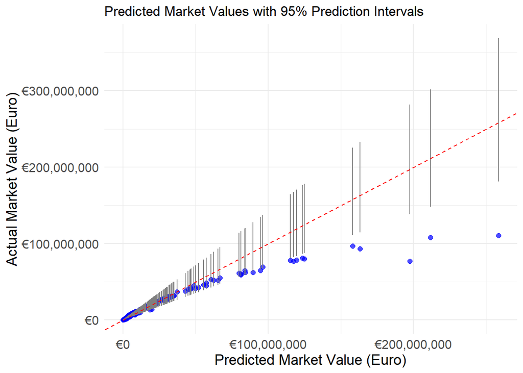

```r
prediction_interval <- exp(predict(
  log_value_model,
  newdata = fifa_data,
  interval = "prediction",
  level = 0.95
))

fifa_data_predictions <- cbind(fifa_data, prediction_interval) |>
  rename(
    predicted_value = fit,
    lower_bound = lwr,
    upper_bound = upr
  )

# Plot actual vs. predicted with prediction intervals
ggplot(fifa_data_predictions, aes(x = predicted_value, y = value_euro)) +
  geom_point(color = "blue", alpha = 0.7, size = 2) +  # Actual values
  geom_errorbar(aes(ymin = lower_bound, ymax = upper_bound), width = 0.2, color = "gray50") +
  labs(
    title = "Predicted Market Values with 95% Prediction Intervals",
    x = "Predicted Market Value (Euro)",
    y = "Actual Market Value (Euro)"
  ) +
  theme_minimal() +
  scale_x_continuous(labels = dollar_format(prefix = "€"))+
  scale_y_continuous(labels = dollar_format(prefix = "€"))+
  geom_abline(intercept = 0, slope = 1, linetype = "dashed", color = "red") +
  theme(
    axis.text = element_text(size = 12),
    axis.title = element_text(size = 14)
  )
```

**Observations** Less than 50million euros we can see that our linear model is a perfect fit and the Actual market value matches the predicted market value. high value players whose value > 50 million euros might have other factors such as injury history, marketing potential etc., which influences their market value.

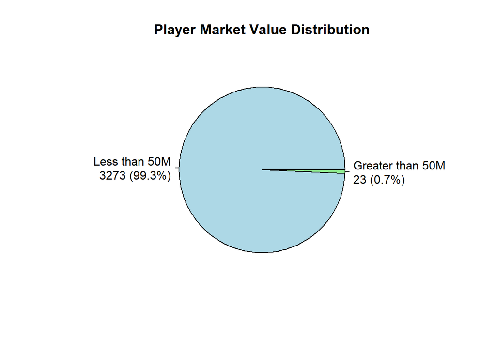

```r
player_counts <- fifa_data |>
  summarise(
    less_than_50 = sum(value_euro < 50000000, na.rm = TRUE),
    greater_than_50 = sum(value_euro > 50000000, na.rm = TRUE)
  )

total <- sum(player_counts$less_than_50, player_counts$greater_than_50)
percentages <- round(c(player_counts$less_than_50, player_counts$greater_than_50) / total * 100, 1)


labels_with_counts_percentages <- paste(
  c("Less than 50M", "Greater than 50M"),
  "\n",
  c(player_counts$less_than_50, player_counts$greater_than_50),
  " (", percentages, "%)",
  sep = ""
)


pie(
  c(player_counts$less_than_50, player_counts$greater_than_50),
  labels = labels_with_counts_percentages,
  main = "Player Market Value Distribution",
  col = c("lightblue", "lightgreen")
)
```

```r
# Create the linear regression model
traits_model <- lm(overall_rating ~ ball_control + dribbling + finishing +
                     positioning + shot_power + stamina +
                     composure + long_shots + reactions +
                     vision + volleys,
                   data = fifa_data)
```

### Interpretation and Observation

```r
vif(traits_model)
```

```
## ball_control    dribbling    finishing  positioning   shot_power      stamina
##     7.332871     4.855570     4.127150     5.759807     3.404632     1.338559
##    composure   long_shots    reactions       vision      volleys
##     3.927081     3.298864     4.483114     2.670967     3.221693
```

```r
vif(log_value_model)
```

```
##      potential overall_rating            age       I(age^2)
##       13.30212       17.71124      366.99430      279.01831
```

### Actionable Insights

**For Player Scouts** - Prioritize young players (age 21-25) with high potential ratings - Focus on players with strong - Ball control (highest correlation to overall rating) - Finishing skills - Positioning - Shot power - Look for players with development potential, as it significantly impacts market value

- Strategy
  - Invest in players under 25 with high potential
  - Prioritize players with ratings above 75
  - Consider long term development over immediate reputation even though that has other benefits